# URDF

## What is URDF?

URDF (Unified Robot Description Format) is an XML format used in ROS (Robot Operating System) to describe the structure, physical properties, and visuals of a robot model. In ROS 2, URDF files are primarily used to simulate the robot in environments like Gazebo and RViz, and to define the robot’s kinematic and dynamic properties.

URDF files allow the robot's properties like links, joints, inertial data, collision properties, and visuals to be described. These files are essential for creating models of robots that can be simulated or controlled in real or virtual environments.

### Purpose of URDF

In ROS 2, URDF is used for:

1. Robot Modeling: Defining the robot’s links, joints, sensors, and actuators.
2. Simulation: Gazebo uses URDF to simulate the robot's behavior in a physics-based environment.
3. Visualization: RViz uses URDF to visualize the robot's model and its movements.
4. Planning and Control: Describes the robot's structure, which is crucial for motion planning, kinematics, and dynamics.

#### Simple URDF

```python
<?xml version="1.0"?>
<robot name="my_robot">
    <material name="green">
        <color rgba="0.0 0.6 0.0 1"/>
    </material>
    <material name="blue">
        <color rgba="0.0 0.0 1.0 1"/>
    </material>
    <material name="white">
        <color rgba="1 1 1 1"/>
    </material>

    <!-- Base Footprint -->
    <link name="base_footprint"/>

    <!-- link name="base_footprint"/ -->

    <!-- Base Link -->
    <link name="base_link">
        <inertial>
            <mass value="1.0"/>
            <origin xyz="0.0 0.0 0.1" rpy="0 0 0"/>
            <inertia ixx="0.02" ixy="0.0" ixz="0.0"
                            iyy="0.02" iyz="0.0" izz="0.02"/>
        </inertial>
        <visual>
            <geometry>
                <box size="0.6 0.4 0.2"/>
            </geometry>
            <origin xyz="0.0 0.0 0.1" rpy="0 0 0"/>
            <material name="blue"/>
        </visual>
        <collision>
            <geometry>
                <box size="0.6 0.4 0.2"/>
            </geometry>
            <origin xyz="0.0 0.0 0.1" rpy="0 0 0"/>
        </collision>
    </link>

    <gazebo reference="base_link">
        <material>Gazebo/Blue</material>
    </gazebo>

    <!-- Lidar -->
    <link name="lidar">
        <inertial>
            <mass value="0.1"/>
            <origin xyz="0.0 0.0 0.05" rpy="0 0 0"/>
            <inertia ixx="0.001" ixy="0.0" ixz="0.0"
                            iyy="0.001" iyz="0.0" izz="0.001"/>
        </inertial>
        <visual>
            <geometry>
                <cylinder radius="0.1" length="0.05"/>
            </geometry>
            <origin xyz="0.0 0.0 0" rpy="0 0 0"/>
            <material name="white"/>
        </visual>
        <collision>
            <geometry>
                <cylinder radius="0.1" length="0.05"/>
            </geometry>
            <origin xyz="0.0 0.0 0" rpy="0 0 0"/>
        </collision>
    </link>

    <!-- Caster Wheel -->
    <link name="caster_wheel">
        <inertial>
            <mass value="0.1"/>
            <origin xyz="0.0 0.0 0" rpy="0 0 0"/>
            <inertia ixx="0.001" ixy="0.0" ixz="0.0"
                                iyy="0.001" iyz="0.0" izz="0.001"/>
        </inertial>
        <visual>
            <geometry>
                <sphere radius="0.05"/>
            </geometry>
            <origin xyz="0.0 0.0 0" rpy="0 0 0"/>
            <material name="white"/>
        </visual>
        <collision>
            <geometry>
                <sphere radius="0.05"/>
            </geometry>
            <origin xyz="0.0 0.0 0" rpy="0 0 0"/>
        </collision>
    </link>

    <!-- Left Wheel -->
    <link name="left_wheel">
        <inertial>
            <mass value="0.2"/>
            <origin xyz="0.0 0.0 0" rpy="0 0 0"/>
            <inertia ixx="0.002" ixy="0.0" ixz="0.0"
                                iyy="0.002" iyz="0.0" izz="0.002"/>
        </inertial>
        <visual>
            <geometry>
                <cylinder radius="0.1" length="0.05"/>
            </geometry>
            <origin xyz="0.0 0.0 0" rpy="1.57 0 0"/>
            <material name="white"/>
        </visual>
        <collision>
            <geometry>
                <cylinder radius="0.1" length="0.05"/>
            </geometry>
            <origin xyz="0.0 0.0 0" rpy="1.57 0 0"/>
        </collision>
    </link>

    <!-- Right Wheel -->
    <link name="right_wheel">
        <inertial>
            <mass value="0.2"/>
            <origin xyz="0.0 0.0 0" rpy="0 0 0"/>
            <inertia ixx="0.002" ixy="0.0" ixz="0.0"
                                iyy="0.002" iyz="0.0" izz="0.002"/>
        </inertial>
        <visual>
            <geometry>
                <cylinder radius="0.1" length="0.05"/>
            </geometry>
            <origin xyz="0.0 0.0 0" rpy="1.57 0 0"/>
            <material name="white"/>
        </visual>
        <collision>
            <geometry>
                <cylinder radius="0.1" length="0.05"/>
            </geometry>
            <origin xyz="0.0 0.0 0" rpy="1.57 0 0"/>
        </collision>
    </link>

    <!-- Joints -->
    <joint name="base_joint" type="fixed">
        <parent link="base_link"/>
        <child link="base_footprint"/>
        <origin xyz="0.0 0.0 0.0" rpy="0 0 0"/>
    </joint>

    <joint name="base_lidar_joint" type="fixed">
        <parent link="base_link"/>
        <child link="lidar"/>
        <origin xyz="0.0 0.0 0.225" rpy="0 0 0"/>
    </joint>

    <joint name="left_wheel_joint" type="continuous">
        <parent link="base_link"/>
        <child link="left_wheel"/>
        <origin xyz="-0.15 -0.225 0.04" rpy="0 0 0"/>
        <axis xyz="0.0 1.0 0.0"/>
    </joint>

    <joint name="right_wheel_joint" type="continuous">
        <parent link="base_link"/>
        <child link="right_wheel"/>
        <origin xyz="-0.15 0.225 0.04" rpy="0 0 0"/>
        <axis xyz="0.0 1.0 0.0"/>
    </joint>

    <joint name="caster_wheel_joint" type="fixed">
        <parent link="base_link"/>
        <child link="caster_wheel"/>
        <origin xyz="0.2 0 -0.01" rpy="0 0 0"/>
    </joint>

    <!-- Gazebo Plugins -->
    <gazebo>
        <plugin name="bot_joint_state"
                    filename="libgazebo_ros_joint_state_publisher.so">
            <ros>
                <remapping>~/out:=joint_states</remapping>
            </ros>
            <update_rate>30</update_rate>
            <joint_name>right_wheel_joint</joint_name>
            <joint_name>left_wheel_joint</joint_name>
            <joint_name>caster_wheel_joint</joint_name>
            <joint_name>base_lidar_joint</joint_name>
        </plugin>
    </gazebo>

    <gazebo>
        <plugin name="differential_drive_controller"
                    filename="libgazebo_ros_diff_drive.so">
            <!-- Wheel Information -->
            <update_rate>30</update_rate>
            <left_joint>left_wheel_joint</left_joint>
            <right_joint>right_wheel_joint</right_joint>
            <wheel_separation>0.36</wheel_separation>
            <wheel_diameter>0.18</wheel_diameter>
            <!-- Limits -->
            <max_wheel_torque>10.0</max_wheel_torque>
            <max_wheel_acceleration>1.0</max_wheel_acceleration>
            <!-- Output -->
            <command_topic>cmd_vel</command_topic>
            <publish_odom>true</publish_odom>
            <publish_odom_tf>true</publish_odom_tf>
            <odometry_frame>odom</odometry_frame>
            <robot_base_frame>base_link</robot_base_frame>
            <publish_wheel_tf>true</publish_wheel_tf>
        </plugin>
    </gazebo>
</robot>
```

### Step-by-Step Explanation of the given URDF code

XML Declaration:

```python
<?xml version="1.0"?>
```

This is the standard XML declaration, specifying the version of XML being used.

Robot Tag:

```python
<robot name="my_robot">
```

Defines the root element for the robot description, named "my_robot". All components (links, joints, etc.) are enclosed within this tag.

Material's Color Definition:

```python
<material name="green">
    <color rgba="0.0 0.6 0.0 1"/>
</material>
```

Defines materials by name, specifying colors using RGBA values. Green, blue, and white materials are defined.

Base Footprint Link:

```python
<link name="base_footprint"/>
```

Defines a simple link with the name "base_footprint", which represents the robot's base footprint.(dummy link)

Base Link:

```python
<!-- Base Link -->
    <link name="base_link">
        <inertial>
            <mass value="1.0"/>
            <origin xyz="0.0 0.0 0.1" rpy="0 0 0"/>
            <inertia ixx="0.02" ixy="0.0" ixz="0.0" iyy="0.02" iyz="0.0" izz="0.02"/>
        </inertial>
        <visual>
            <geometry>
                <box size="0.6 0.4 0.2"/>
            </geometry>
            <origin xyz="0.0 0.0 0.1" rpy="0 0 0"/>
            <material name="blue"/>
        </visual>
        <collision>
            <geometry>
                <box size="0.6 0.4 0.2"/>
            </geometry>
            <origin xyz="0.0 0.0 0.1" rpy="0 0 0"/>
        </collision>
    </link>

    <gazebo reference="base_link">
        <material>Gazebo/Blue</material>
    </gazebo>
```

A link named "base_link" is defined. It is the core part of the robot.

Specifies the mass (1 kg), center of mass, and inertia matrix of the base link. This helps Gazebo simulate its dynamic properties.

Describes the visual appearance using a box shape of size 0.6x0.4x0.2 meters, positioned at a specified origin. The material is set to blue.

Describes the geometry used for collision detection in simulations. It uses the same dimensions and position as the visual box.

Specifies the material color for the robot when visualized in Gazebo.

Lidar Link:

```python
<link name="lidar"> //Defines a new link representing the Lidar sensor.
```

Inertial, Visual, and Collision Properties for Lidar:

1. The inertial section defines the mass and inertia properties for the Lidar sensor.
2. Visual and collision elements describe the sensor as a cylinder of radius 0.1 and length 0.05.

Caster Wheel Link:

```python
<link name="caster_wheel">
//Defines a caster wheel as a spherical link with radius 0.05,
//used to support the robot.
```

Left and Right Wheels:

Both the left and right wheels are represented as cylinders with radius 0.1 and length 0.05. Their inertial properties, visual geometry, and collision properties are specified similarly.

Joints:

```python
<joint name="base_joint" type="fixed">
    <parent link="base_link"/>
    <child link="base_footprint"/>
    <origin xyz="0.0 0.0 0.0" rpy="0 0 0"/>
</joint>
```

Joints connect two links. The "base_joint" is a fixed joint that connects "base_link" and "base_footprint".

The "left_wheel_joint" and "right_wheel_joint" are continuous (rotational) joints that allow the wheels to rotate.

Gazebo Plugins:

Joint State Publisher Plugin:

```python
<plugin name="bot_joint_state"
        filename="libgazebo_ros_joint_state_publisher.so">
```

This plugin publishes joint states of the robot to ROS topics. It maps joints to the joint_states topic.

Differential Drive Controller Plugin:

```python
<plugin name="differential_drive_controller"
        filename="libgazebo_ros_diff_drive.so">
```

This plugin controls the differential drive (wheeled) motion of the robot. It handles velocity commands and publishes odometry data.

The URDF concludes with the "</ robot >" tag to close the robot definition.

### Launch URDF without Launch file:

```python
ros2 launch urdf_tutorial display.launch.py model:=/home/user/path to/urdf_file.urdf
```

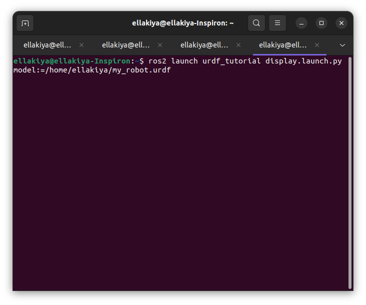

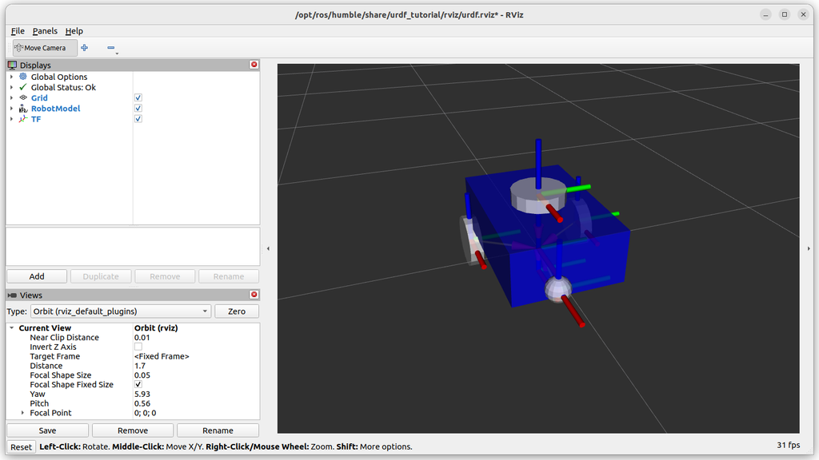

Replace user, path to , urdf files by actual user name, directory of urdf files

## Simple Launch Files

### What are ROS Launch ?

In ROS (Robot Operating System), a launch file is an XML or Python-based script that automates the launching of multiple nodes, parameters, and settings in a structured and efficient way. Launch files streamline the process of starting a robot system, making it easy to run a complex set of nodes and configurations without manually typing each command.

For ROS 2, launch files are generally written in Python, but they can also be written in XML, depending on the ROS distribution.

### Purpose of Launch Files

1. **Launch Multiple Nodes Simultaneously:**  
   Launch files can start multiple ROS nodes at once. This is useful when you have a complex system with many components (e.g., sensors, controllers, state publishers) that need to run simultaneously.
2. **Specify Node Parameters:**  
   You can pass parameters to nodes through launch files. For example, you can configure the behavior of a node by setting specific parameters related to robot description, controller settings, etc.
3. **Manage Simulation Environments:**  
   When using simulators like Gazebo or visualization tools like RViz, launch files can be used to configure and launch these environments, along with the robots or sensors.
4. **Load Robot Descriptions:**  
   Launch files can load robot description files like URDF or SDF into the system, allowing the simulation environment (such as Gazebo) or visualization tools (like RViz) to use them.

### Components of a Launch File

1. **Nodes:** The core component of a launch file. A node corresponds to an executable in a ROS package that performs some task (e.g., reading sensors, controlling actuators).
2. **Parameters:** Configuration values passed to nodes, allowing you to define aspects like robot descriptions, sensor update rates, or controller settings.
3. **Launch Actions:** These can include commands for launching other launch files, starting nodes, or running scripts.
4. **Launch Arguments:** Provide input flexibility to launch files by allowing users to specify certain values when launching, such as robot type, environment settings, or topic names.
5. **Include Statements:** Allow including other launch files within a launch file, which is useful for breaking down complex systems into more manageable components.

Launch files make it easy to manage complex robot systems by starting multiple nodes, setting configurations, and managing dependencies in a structured and automated way. They are essential for running, testing, and deploying robot applications in a real or simulated environment in ROS 2.

### Gazebo Launch file for visualizing above URDF:

```python
import os
from ament_index_python.packages import get_package_share_directory
from launch import LaunchDescription
from launch.actions import IncludeLaunchDescription
from launch.launch_description_sources import PythonLaunchDescriptionSource
from launch_ros.actions import Node
from launch.substitutions import Command, LaunchConfiguration

def generate_launch_description():
    # Path to your robot description
    robot_description_path = os.path.join(
        get_package_share_directory('bot'),
        'urdf',
        'trial.urdf'
    )

    # Command to load URDF into parameter
    robot_state_publisher_cmd = Node(
        package='robot_state_publisher',
        executable='robot_state_publisher',
        output='screen',
        parameters=[{'robot_description':
                     Command(['xacro ', robot_description_path])}]
    )

    # Spawn the robot in Gazebo
    spawn_entity_cmd = Node(
        package='gazebo_ros',
        executable='spawn_entity.py',
        arguments=['-entity', 'my_robot', '-file', robot_description_path],
        output='screen'
    )

    # Launch Gazebo
    gazebo_cmd = IncludeLaunchDescription(
        PythonLaunchDescriptionSource([os.path.join(
            get_package_share_directory('gazebo_ros'),
            'launch', 'gazebo.launch.py')])
    )

    return LaunchDescription([
        gazebo_cmd,
        robot_state_publisher_cmd,
        spawn_entity_cmd,
    ])
```

Importing:

```python
import os
from ament_index_python.packages import get_package_share_directory
from launch import LaunchDescription
from launch.actions import IncludeLaunchDescription
from launch.launch_description_sources import PythonLaunchDescriptionSource
from launch_ros.actions import Node
from launch.substitutions import Command, LaunchConfiguration
```

os: Used to manage file paths.  
ament_index_python.packages.get_package_share_directory: Retrieves the path to a package’s shared directory.  
launch.LaunchDescription: Defines a ROS 2 launch description, which is a collection of nodes and other actions to execute.  
launch.actions.IncludeLaunchDescription: Includes other launch files into the current launch file.  
launch.launch_description_sources.PythonLaunchDescriptionSource: Specifies that a launch file is written in Python.  
launch_ros.actions.Node: Used to define and launch ROS 2 nodes.  
launch.substitutions.Command and LaunchConfiguration: Used to manage substitutions, i.e., replacing parts of the command during runtime.

Defining the path of the robot by defining the function

```python
def generate_launch_description():
```

```python
robot_description_path = os.path.join(
    get_package_share_directory('bot'),
    'urdf',
    'trial.urdf'
)
```

This constructs the path to the URDF file trial.urdf located in the urdf folder within the bot package. URDF (Unified Robot Description Format) is an XML format used in ROS to describe the structure and physical properties (like links and joints) of a robot.

Node: robot_state_publisher to Publish Robot Description

```python
robot_state_publisher_cmd = Node(
    package='robot_state_publisher',
    executable='robot_state_publisher',
    output='screen',
    parameters=[{'robot_description':
                 Command(['xacro ', robot_description_path])}]
)
```

This node runs the robot_state_publisher package.  
robot_state_publisher: Publishes the state of the robot based on the URDF.  
Command: The substitution Command(['xacro ', robot_description_path]) converts the URDF file into the robot description parameter using xacro (a tool for generating URDFs from templates).

Node: spawn_entity.py to Spawn Robot in Gazebo

```python
spawn_entity_cmd = Node(
    package='gazebo_ros',
    executable='spawn_entity.py',
    arguments=['-entity', 'my_robot', '-file', robot_description_path],
    output='screen'
)
```

This node spawns the robot described by the URDF into the Gazebo simulation environment.

##### Arguments:

-entity my_robot: The name of the robot entity in Gazebo. -file robot_description_path: Path to the robot description file.

Including the Gazebo Launch File:

```python
gazebo_cmd = IncludeLaunchDescription(
    PythonLaunchDescriptionSource([os.path.join(
        get_package_share_directory('gazebo_ros'), 'launch', 'gazebo.launch.py')])
)
```

This includes the default Gazebo launch file from the gazebo_ros package, which sets up the Gazebo simulator for ROS 2.

Returning the Launch Description

```python
return LaunchDescription([
    gazebo_cmd,
    robot_state_publisher_cmd,
    spawn_entity_cmd,
])
```

**The LaunchDescription contains all the necessary commands to:**

1. Launch Gazebo (gazebo_cmd).
2. Publish the robot's state (robot_state_publisher_cmd).
3. Spawn the robot in Gazebo (spawn_entity_cmd).

### Rviz Launch File:

```python
import launch
from launch.substitutions import LaunchConfiguration
import launch_ros
import os

def generate_launch_description():
    pkgPath = launch_ros.substitutions.FindPackageShare(package='bot').find('bot')
    urdfModelPath= os.path.join(pkgPath, 'urdf/trial.urdf')

    with open(urdfModelPath,'r') as infp:
    	robot_desc = infp.read()

    params = {'robot_description': robot_desc}

    robot_state_publisher_node =launch_ros.actions.Node(
    package='robot_state_publisher',
	executable='robot_state_publisher',
    output='screen',
    parameters=[params])


    joint_state_publisher_node = launch_ros.actions.Node(
        package='joint_state_publisher',
        executable='joint_state_publisher',
        name='joint_state_publisher',
        parameters=[params],
        condition=launch.conditions.UnlessCondition
            (LaunchConfiguration('gui'))
    )
    joint_state_publisher_gui_node = launch_ros.actions.Node(
        package='joint_state_publisher_gui',
        executable='joint_state_publisher_gui',
        name='joint_state_publisher_gui',
        condition=launch.conditions.IfCondition
            (LaunchConfiguration('gui'))
    )

    rviz_node = launch_ros.actions.Node(
        package='rviz2',
        executable='rviz2',
        name='rviz2',
        output='screen'
    )

    return launch.LaunchDescription([
        launch.actions.DeclareLaunchArgument
        (name='gui', default_value='True',
                description='This is a flag for joint_state_publisher_gui'),
        launch.actions.DeclareLaunchArgument
        (name='model', default_value=urdfModelPath,
                description='Path to the urdf model file'),
        robot_state_publisher_node,
        joint_state_publisher_node,
        joint_state_publisher_gui_node,
        rviz_node
    ])
```

This launch file configures and launches nodes necessary for visualizing a robot model in RViz, using URDF and state publishers.

1. **URDF Loading:** The URDF file (trial.urdf) is loaded from the 'bot' package and passed as the robot_description parameter.
2. **Nodes:**  
   **robot_state_publisher:** Publishes the state of the robot to transform frames using the URDF model.  
   **joint_state_publisher:** Publishes the robot’s joint states, used when the gui flag is False.  
   **joint_state_publisher_gui:** Provides a graphical interface to control joint states, launched when the gui flag is True.  
   **rviz2:** Launches RViz for robot model visualization.
3. **Launch Arguments:**gui: Flag to toggle between the joint_state_publisher and joint_state_publisher_gui.  
   model: Defines the path to the URDF model.

### Launch the Code:

To run the gazebo launch file:

```python
ros2 launch package_name gazebo_launch_file_name
```

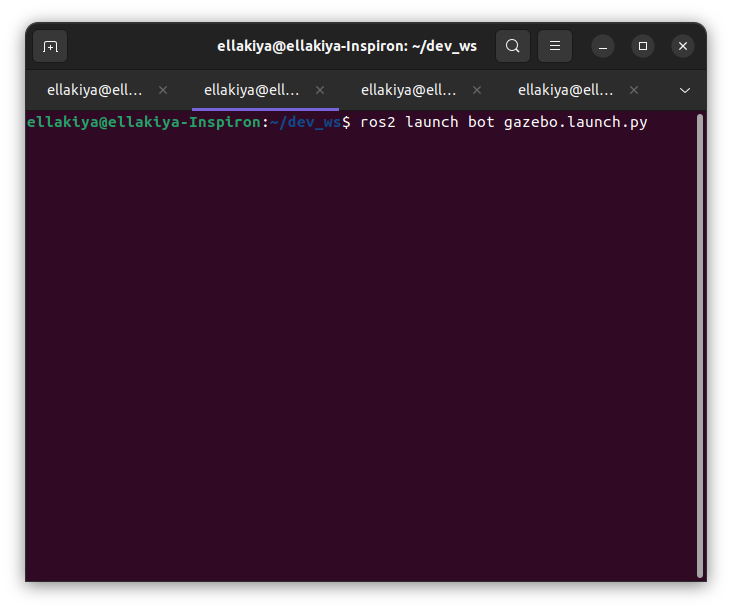

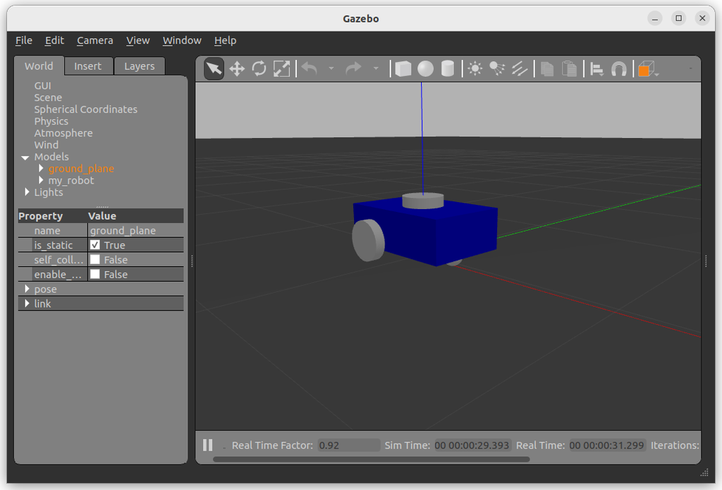

To run the rviz launch file:

```python
ros2 launch package_name rviz_launch_file_name
```

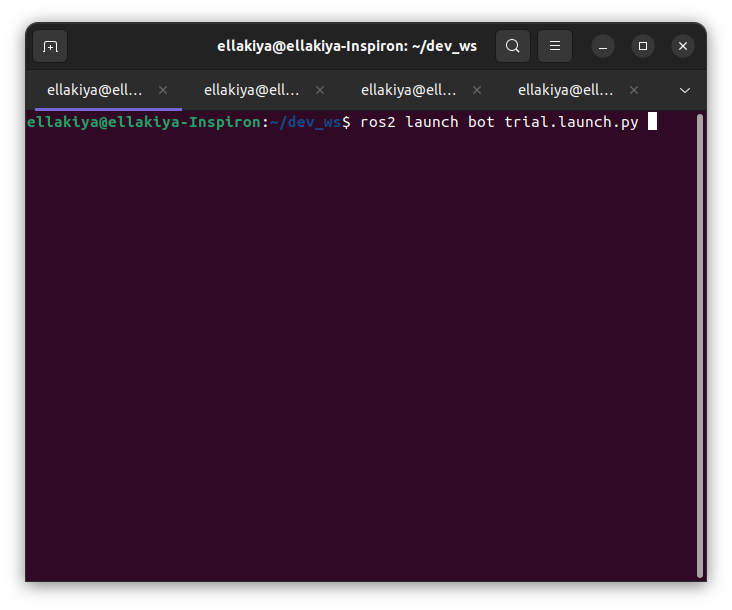

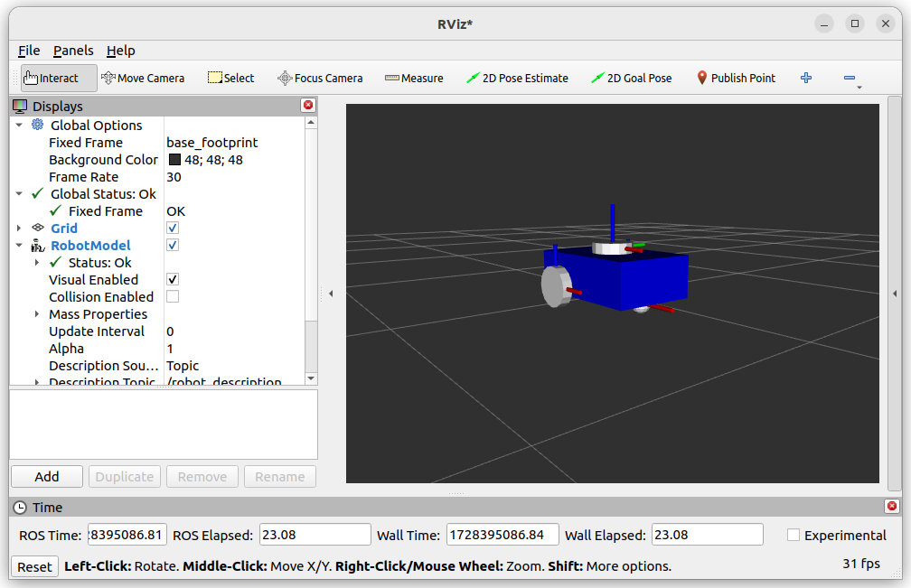

## Teleoperation

Teleoperation refers to the remote control of a machine or robot by a human operator. In robotics, teleoperation is a method where the user interacts with the robot from a distance, typically through a user interface, to perform tasks. This is commonly done using devices like joysticks, keyboards, or specialized control interfaces.

In ROS, teleoperation is often implemented using a keyboard, joystick, or game controller to send velocity commands to the robot’s motion controller. This can be done using the `teleop_twist_keyboard` package to control a mobile robot's movement or a robotic arm.

To run the robot using teleoperation:

```python
ros2 run teleop_twist_keyboard teleop_twist_keyboard
```

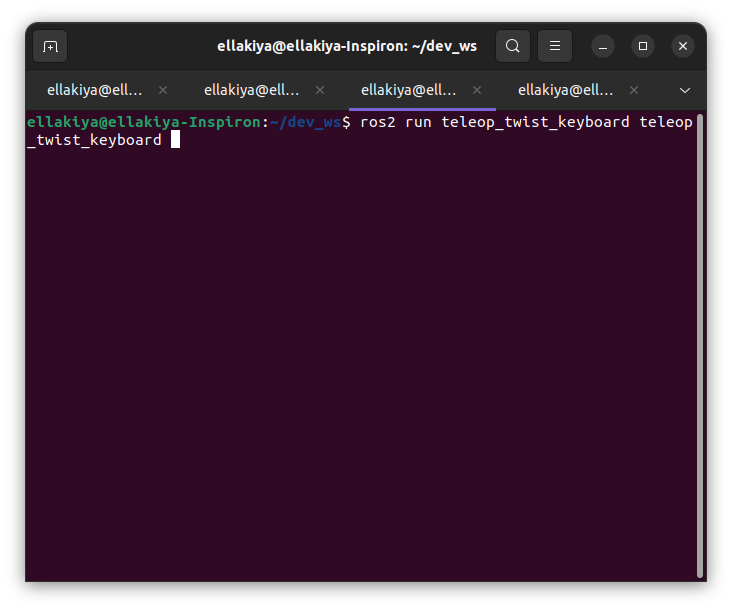

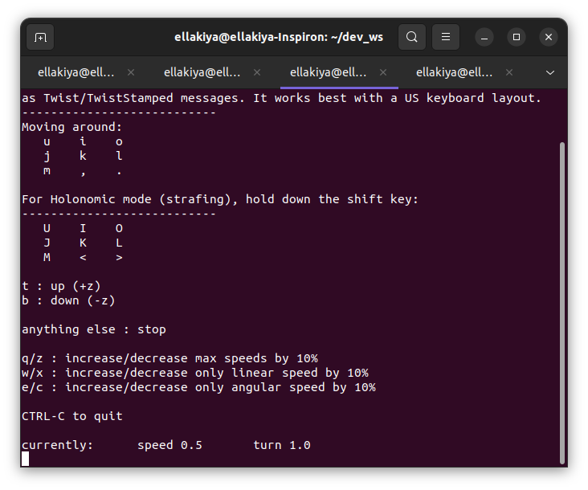

1. Move the robot by using u,i,o,j,k,l,m,,,. keys
2. Control the speed by using q/z,w/x,e/c keys

This configuration is designed to control a robot's movement in a detailed and flexible manner, supporting both linear and angular adjustments with real-time feedback on the robot's current speed settings.